# Toets voor twee verwachtingen - afhankelijke steekproeven

Op deze pagina wordt een statistische techniek gedemonstreerd aan de hand van een voorbeeld. Meer informatie over hoe je deze pagina kan gebruiken vind je in deze handleiding.

De analyse gebeurt met behulp van R en RStudio. Een inleiding tot deze software vind je [hier](https://ufora.ugent.be/d2l/le/discovery/view/course/386505).

# 1 Doel

Met deze toets kan je nagaan of er een verschil is tussen twee groepen waarbij de individuele metingen in beide groepen rechtstreeks gelinkt zijn aan elkaar, bijvoorbeeld metingen bij een persoon voor en na een behandeling.

## Beter alternatief?

De toets die in dit voorbeeld wordt gedemonstreerd is een statistische techniek die tegenwoordig minder vaak wordt gebruikt.

De reden hiervoor is dat er een beter alternatief is: met een repeated measures analyse kan je indien gewenst meerdere predictoren en meer dan twee metingen analyseren.

# 2 Voorbeeld

In een poging om de interesse voor het vak geschiedenis op te krikken, laat je leerlingen uit het secundair onderwijs een hele les op zoek gaan naar informatie over een zelfgekozen onderwerp. Je verwacht dat deze vorm van zelfgestuurd leren de interesse voor het vak zal verhogen.

Je verzamelt gegevens om je vermoeden te onderzoeken. Je trekt een steekproef van leerlingen en je bevraagt hen voor en na de les.

# 3 Data importeren

De data bij dit voorbeeld kan je met het onderstaande commando importeren in R.

```r
mijn_data <- read.csv("https://statlas.ugent.be/datasets/interesse.csv")
```

Inspecteer de data met de functie `str()`.

```r
str(mijn_data)
```

```
'data.frame':   23 obs. of  4 variables:
 $ leeftijd  : int  12 15 18 12 13 16 18 14 17 13 ...
 $ geslacht  : chr  "M" "M" "M" "V" ...
 $ score.voor: num  44.1 75.4 67.3 66.1 50.4 62.3 73 84.3 66.8 72.7 ...
 $ score.na  : num  73.9 77.1 70.1 78 74.2 66.1 73.7 62 82.5 86.8 ...
```

# 4 Hypothesen

De hypothesen die bij deze toets horen zijn:

$H_0: \mu_{na} = \mu_{voor}$ of $\mu_{na}-\mu_{voor} = 0$

$H_a: \mu_{na} > \mu_{voor}$ of $\mu_{na}-\mu_{voor} > 0$

De alternatieve hypothese $H_a$ is hier eenzijdig. Meer uitleg over eenzijdig versus tweezijdig toetsen vind je hier.

# 5 Data verkennen

In dit voorbeeld wil je de interesse voor de les vergelijken met de interesse na de les. Met de functie `summary()` krijg je een eerste indruk van de variabelen in de dataset. Je ziet dat het gemiddelde (`Mean`) van de interesse na de les iets hoger ligt dan ervoor. Verderop zullen we ons de vraag stellen of dit verschil aan toeval kan liggen.

```r
summary(mijn_data)
```

```
    leeftijd       geslacht           score.voor       score.na
 Min.   :12.00   Length:23          Min.   :44.10   Min.   :56.60
 1st Qu.:13.00   Class :character   1st Qu.:62.65   1st Qu.:69.00
 Median :15.00   Mode  :character   Median :66.80   Median :72.50
 Mean   :14.96                      Mean   :66.72   Mean   :72.97
 3rd Qu.:17.00                      3rd Qu.:73.85   3rd Qu.:76.80
 Max.   :18.00                      Max.   :84.30   Max.   :90.20
```

Een eerste, visuele indruk van de gegevens kan je verkrijgen door twee boxplots te maken: één voor de meting voor de les en één voor de meting na de les. Met de code hieronder zorg je ervoor dat de beide boxplots in één figuur worden getoond.

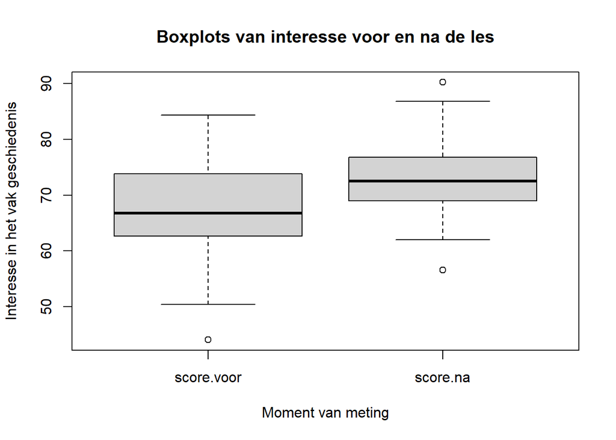

```r
boxplot(mijn_data$score.voor, mijn_data$score.na, # Twee vectoren met data, dus er worden twee boxplots gemaakt
        main="Boxplots van interesse voor en na de les",
        names=colnames(mijn_data)[3:4],
        xlab="Moment van meting",
        ylab="Interesse in het vak geschiedenis"
        )
```

# 6 Keuze toets

We vergelijken de verwachtingen in twee groepen. De steekproeven zijn afhankelijk: er is een directe link tussen een meting uit de ene groep en een meting uit de andere groep. De metingen worden namelijk bij dezelfde leerling uitgevoerd.

Deze toets kunnen we uitvoeren met behulp van de functie `t.test()`.

## Assumpties

- De variabele moet tenminste van intervalniveau zijn. Dat is het geval in dit voorbeeld.
- Daarnaast:
  - ofwel moet de steekproef voldoende groot zijn (de vuistregel is $n \geq 30$).

    ```r
    dim(mijn_data)[1] # Met deze code vraag je hoeveel rijen er zijn in de dataset
    ```

    ```
    [1] 23
    ```

    Er zijn slechts 23 observaties (leerlingen), dus de steekproef is niet groot genoeg.
  - ofwel moet het verschil tussen de beide metingen normaal verdeeld zijn. Dit kan je nagaan door een nieuwe vector aan te maken, die berekend wordt als het verschil `score.na - score.voor`. Van die nieuwe vector `d` vraag je vervolgens een QQ-plot op. Hier zie je wel enkele afwijkingen, maar slechts bij een kleine minderheid van datapunten. Je kan de toets uitvoeren, maar je zal misschien voorzichtig moeten zijn bij het maken van een conclusie.

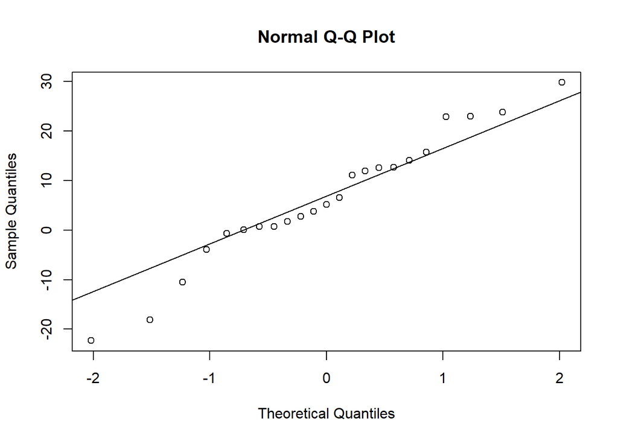

    ```r
    d <- mijn_data$score.na - mijn_data$score.voor
    qqnorm(d)
    qqline(d)
    ```

# 7 Significantieniveau

Voor je de toets uitvoert, moet je een significantieniveau $\alpha$ kiezen.

```r
alpha <- 0.05
```

# 8 Toets

Met onderstaande code kan je de toets uitvoeren. Let op het argument `paired=TRUE`. Dit is nodig omdat het om afhankelijke steekproeven gaat.

```r
t.test(x=mijn_data$score.na, y=mijn_data$score.voor, alternative="greater", conf.level=1-alpha, paired=TRUE)
```

```
    Paired t-test

data:  mijn_data$score.na and mijn_data$score.voor
t = 2.3143, df = 22, p-value = 0.01519
alternative hypothesis: true difference in means is greater than 0
95 percent confidence interval:
 1.612091      Inf
sample estimates:
mean of the differences
               6.247826
```

# 9 Conclusie